# ds202_finalproject

Emily Pollock

4/19/2021

```r
library(lubridate)
library(tidyverse)
library(dplyr)
```

```r
deathsByAge <- readr::read_csv('deaths_by_age_group.csv')

casesByAge <- readr::read_csv('cases_by_age_group.csv')

covid19Data <- readr::read_csv('covid19_vaccinations_in_the_united_states.csv')

casesdeathsstates <- readr::read_csv('united_states_covid19_cases_and_deaths_by_state.csv')

deathsByAge
```

```
## # A tibble: 9 x 4
##   `Age Group` `Percentage of deaths` `Count of deaths` `Percent of US populatio…
##   <chr>       <chr>                              <dbl>                     <dbl>
## 1 0-4 Years   <0.1                                 108                       6
## 2 5-17 Years  0.1                                  244                      16.3
## 3 18-29 Years 0.5                                 2063                      16.4
## 4 30-39 Years 1.1                                 4890                      13.5
## 5 40-49 Years 2.8                                12051                      12.3
## 6 50-64 Years 14.6                               62492                      19.2
## 7 65-74 Years 21.4                               91108                       9.6
## 8 75-84 Years 27.7                              118007                       4.9
## 9 85+ Years   31.8                              135707                       2
```

```r
casesByAge
```

```
## # A tibble: 9 x 4
##   `Age Group` `Percent of cases` `Count of cases` `Percent of US population`
##   <chr>                    <dbl>            <dbl>                      <dbl>
## 1 0-4 Years                  2             476372                        6
## 2 5-17 Years                 9.8          2324060                       16.3
## 3 18-29 Years               22.4          5320608                       16.4
## 4 30-39 Years               16.4          3888891                       13.5
## 5 40-49 Years               14.9          3543373                       12.3
## 6 50-64 Years               20.5          4881153                       19.2
## 7 65-74 Years                7.7          1830176                        9.6
## 8 75-84 Years                4             956408                        4.9
## 9 85+ Years                  2.4           560301                        2
```

```r
covid19Data
```

```
## # A tibble: 63 x 51
##    `State/Territor… `Total Doses De… `Doses Delivere… `18+ Doses Deli…
##    <chr>                       <dbl> <chr>            <chr>
##  1 Alaska                     658125 89964            119320
##  2 Alabama                   3106870 63364            81441
##  3 Arkansas                  1977830 65539            85338
##  4 American Samoa              43810 78669            100859
##  5 Arizona                   4762745 65434            84469
##  6 Bureau of Priso…           123170 N/A              N/A
##  7 California               26977640 68277            88112
##  8 Colorado                  3720990 64615            82703
##  9 Connecticut               2805115 78679            98847
## 10 District of Col…           562645 79723            97414
## # … with 53 more rows, and 47 more variables: `Total Doses Administered by
## #   State where Administered` <dbl>, `Doses Administered per 100k by State
## #   where Administered` <chr>, `18+ Doses Administered by State where
## #   Administered` <dbl>, `18+ Doses Administered per 100K by State where
## #   Administered` <chr>, `People with at least One Dose by State of
## #   Residence` <dbl>, `Percent of Total Pop with at least One Dose by State of
## #   Residence` <chr>, `People 18+ with at least One Dose by State of
## #   Residence` <dbl>, `Percent of 18+ Pop with at least One Dose by State of
## #   Residence` <chr>, `People Fully Vaccinated by State of Residence` <dbl>,
## #   `Percent of Total Pop Fully Vaccinated by State of Residence` <chr>,
## #   `People 18+ Fully Vaccinated by State of Residence` <dbl>, `Percent of 18+
## #   Pop Fully Vaccinated by State of Residence` <chr>, `Total Number of Pfizer
## #   doses delivered` <dbl>, `Total Number of Moderna doses delivered` <dbl>,
## #   `Total Number of Janssen doses delivered` <dbl>, `Total Number of doses
## #   from unknown manufacturer delivered` <dbl>, `Total Number of Janssen doses
## #   administered` <dbl>, `Total Number of Moderna doses administered` <dbl>,
## #   `Total Number of Pfizer doses adminstered` <dbl>, `Total Number of doses
## #   from unknown manufacturer administered` <dbl>, `People Fully Vaccinated
## #   Moderna Resident` <dbl>, `People Fully Vaccinated Pfizer Resident` <dbl>,
## #   `People Fully Vaccinated Janssen Resident` <dbl>, `People Fully Vaccinated
## #   Unknown 2-dose manufacturer Resident` <dbl>, `People 18+ Fully Vaccinated
## #   Moderna Resident` <dbl>, `People 18+ Fully Vaccinated Pfizer
## #   Resident` <dbl>, `People 18+ Fully Vaccinated Janssen Resident` <dbl>,
## #   `People 18+ Fully Vaccinated Unknown 2-dose manufacturer Resident` <dbl>,
## #   `People with 2 Doses by State of Residence` <dbl>, `Percent of Total Pop
## #   with 1+ Doses by State of Residence` <chr>, `People 18+ with 1+ Doses by
## #   State of Residence` <dbl>, `Percent of 18+ Pop with 1+ Doses by State of
## #   Residence` <chr>, `Percent of Total Pop with 2 Doses by State of
## #   Residence` <dbl>, `People 18+ with 2 Doses by State of Residence` <dbl>,
## #   `Percent of 18+ Pop with 2 Doses by State of Residence` <dbl>, `People with
## #   1+ Doses by State of Residence` <dbl>, `People 65+ with at least One Dose
## #   by State of Residence` <dbl>, `Percent of 65+ Pop with at least One Dose by
## #   State of Residence` <dbl>, `People 65+ Fully Vaccinated by State of
## #   Residence` <dbl>, `Percent of 65+ Pop Fully Vaccinated by State of
## #   Residence` <dbl>, `People 65+ Fully Vaccinated_Moderna_Resident` <dbl>,
## #   `People 65+ Fully Vaccinated_Pfizer_Resident` <dbl>, `People 65+ Fully
## #   Vaccinated_Janssen_Resident` <dbl>, `People 65+ Fully Vaccinated_Unknown
## #   2-dose Manuf_Resident` <dbl>, `65+ Doses Administered by State where
## #   Administered` <dbl>, `Doses Administered per 100k of 65+ pop by State where
## #   Administered` <dbl>, `Doses Delivered per 100k of 65+ pop` <dbl>
```

```r
casesdeathsstates
```

```
## # A tibble: 61 x 13
##    `State/Territor… `Total Cases` `Confirmed Case… `Probable Cases`
##    <chr>                    <dbl>            <dbl>            <dbl>
##  1 Alaska                   61401                0                0
##  2 Alabama                 516918           402538           114380
##  3 Arkansas                331098                0                0
##  4 American Samoa               0                0                0
##  5 Arizona                 844910           784860            60050
##  6 California             3582463                0                0
##  7 Colorado                468988           439872            29116
##  8 Connecticut             316655           291943            24712
##  9 District of Col…         45112                0                0
## 10 Delaware                 96577            90741             5836
## # … with 51 more rows, and 9 more variables: `Cases in Last 7 Days` <dbl>,
## #   `Case Rate per 100000` <dbl>, `Total Deaths` <dbl>, `Confirmed
## #   Deaths` <chr>, `Probable Deaths` <chr>, `Deaths in Last 7 Days` <dbl>,
## #   `Death Rate per 100000` <dbl>, `7-Day Cases Rate per 100000` <dbl>, `7-Day
## #   Death Rate per 100000` <dbl>
```

#Which states have the highest amount of cases (pick top five)? Have these states also administered the most vaccinations? Which vaccine is the most popular for fully vaccinated people in these states?

```r
casesdeathsstates1 <- casesdeathsstates %>%
  rename(State = `State/Territory`, ) %>%
  select(State, `Cases in Last 7 Days`) %>%
  top_n(6, `Cases in Last 7 Days`)
```

```r
casesdeathsstates2 <- casesdeathsstates %>%
  rename(State = `State/Territory`, ) %>%
  select(State, `Total Cases`) %>%
  top_n(6, `Total Cases`)
```

```r
covid19Data1 <- covid19Data %>%
  select(State, total.Doses.Administered) %>%
  top_n(5, total.Doses.Administered)
```

```r
casesdeathsstates1
```

```
## # A tibble: 6 x 2
##   State                    `Cases in Last 7 Days`
##   <chr>                                     <dbl>
## 1 Florida                                   36872
## 2 Michigan                                  47036
## 3 New Jersey                                29753
## 4 New York                                  27496
## 5 Pennsylvania                              30132
## 6 United States of America                 444351
```

```r
casesdeathsstates2
```

```
## # A tibble: 6 x 2
##   State                    `Total Cases`
##   <chr>                            <dbl>
## 1 California                     3582463
## 2 Florida                        2046280
## 3 Georgia                        1065197
## 4 Illinois                       1258736
## 5 Texas                          2794483
## 6 United States of America      30596830
```

```r
covid19Data1
```

```
## # A tibble: 5 x 2
##   State        total.Doses.Administered
##   <chr>                           <dbl>
## 1 California                   20485651
## 2 Florida                      10645680
## 3 New York                     10761342
## 4 Pennsylvania                  6802632
## 5 Texas                        13297711
```

```r
casesdeathsstates2
```

```
## # A tibble: 6 x 2
##   State                    `Total Cases`
##   <chr>                            <dbl>
## 1 California                     3582463
## 2 Florida                        2046280
## 3 Georgia                        1065197
## 4 Illinois                       1258736
## 5 Texas                          2794483
## 6 United States of America      30596830
```

#After sorting the COVID case data by the top five states with the highest total cases, we found that California, Texas, Florida, Illinois and Georgia have had the highest total cases over the course of the pandemic so far. All of these states have case totals over one million, but California comes out on top with a whopping 3,582,463 cases. It is no surprise that the states with the highest cases are also in the top 10 for the most populous states in the U.S.

```r
covid19Data2 <- covid19Data %>%
  filter(State != 'American Samoa', State != 'Bureau of Prisons', State != 'District of Columbia', State != 'Dept of Defense', State != 'Federated States of Micronesia', State != 'Guam', State != 'Indian Health Svc', State != 'Marshall Islands', State != 'Northern Mariana Islands', State != 'Puerto Rico', State != 'Republic of Palau', State != 'Veterans Health', State != 'Virgin Islands')
covid19Data2
```

```
## # A tibble: 50 x 51
##    State total.Doses doses.Per.100K doses.Per.100K.… total.Doses.Adm…
##    <chr>       <dbl>          <dbl>            <dbl>            <dbl>
##  1 Alas…      658125          89964           119320           432690
##  2 Alab…     3106870          63364            81441          1896920
##  3 Arka…     1977830          65539            85338          1325141
##  4 Ariz…     4762745          65434            84469          3809075
##  5 Cali…    26977640          68277            88112         20485651
##  6 Colo…     3720990          64615            82703          3017904
##  7 Conn…     2805115          78679            98847          2186180
##  8 Dela…      673975          69213            87507           519065
##  9 Flor…    14715115          68513            85316         10645680
## 10 Geor…     6663635          62761            82130          4281437
## # … with 40 more rows, and 46 more variables:
## #   doses.Administered.Per.100k <dbl>, doses.Administered.18plus <dbl>,
## #   doses.Administered.18plus.Per.100k <dbl>, people.at.Least.One.Dose <dbl>,
## #   percent.at.Least.One.Dose <dbl>, people.at.Least.One.Dose.18plus <dbl>,
## #   percent.at.Least.One.Dose.18plus <dbl>, people.Fully.Vaccinated <dbl>,
## #   percent.Fully.Vaccinated <dbl>, people.Fully.Vaccinated.18plus <dbl>,
## #   percent.Fully.Vaccinated.18plus <dbl>, doses.Delivered.Pfizer <dbl>,
## #   doses.Delivered.Moderna <dbl>, doses.Delivered.Janssen <dbl>,
## #   doses.Delivered.Unknown <dbl>, doses.Administered.Janssen <dbl>,
## #   doses.Administered.Moderna <dbl>, doses.Administered.Pfizer <dbl>,
## #   doses.Administered.Unknown <dbl>, people.Fully.Vaccinated.Moderna <dbl>,
## #   people.Fully.Vaccinated.Pfizer <dbl>,
## #   people.Fully.Vaccinated.Janssen <dbl>,
## #   people.Fully.Vaccinated.Unknown <dbl>,
## #   people.Fully.Vaccinated.Moderna.18plus <dbl>,
## #   people.Fully.Vaccinated.Pfizer.18plus <dbl>,
## #   people.Fully.Vaccinated.Janssen.18plus <dbl>,
## #   people.Fully.Vaccinated.Unknown.18plus <dbl>, people.Two.Doses <dbl>,
## #   percent.1plus.Doses <dbl>, Oneplus.Doses.18plus <dbl>,
## #   percent.1plus.Doses.18plus <dbl>, percent.2Doses <dbl>,
## #   people.18plus.2Doses <dbl>, percent.18plus.2Doses <dbl>,
## #   people.1plus.Doses <dbl>, people.1plus.Doses.65plus <dbl>,
## #   percent.1plus.Doses.65plus <dbl>, people.Fully.Vaccinated.65plus <dbl>,
## #   percent.Fully.Vaccinated.65plus <dbl>,
## #   people.Fully.Vaccinated.Moderna.65plus <dbl>,
## #   people.Fully.Vaccinated.Pfizer.65plus <dbl>,
## #   people.Fully.Vaccinated.Janssen.65plus <dbl>,
## #   people.Fully.Vaccinated.Unknown.65plus <dbl>,
## #   doses.Administered.65plus <dbl>, doses.Administered.Per.100K.65plus <dbl>,
## #   doses.Delivered.Per.100K.65plus <dbl>
```

```r
covid19Data1
```

```
## # A tibble: 5 x 2
##   State        total.Doses.Administered
##   <chr>                           <dbl>
## 1 California                   20485651
## 2 Florida                      10645680
## 3 New York                     10761342
## 4 Pennsylvania                  6802632
## 5 Texas                        13297711
```

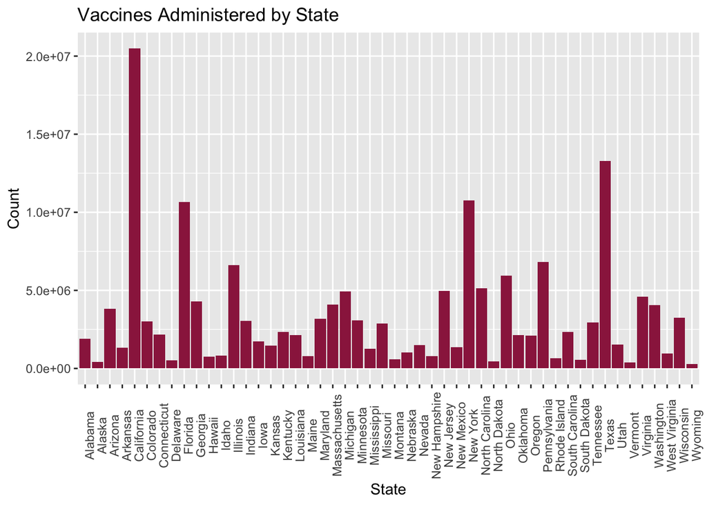

```r
ggplot(covid19Data2, aes(x = State, weight = total.Doses.Administered)) + geom_bar(fill = "#9C254D") + theme(axis.text.x = element_text(angle = 90)) + ggtitle("Vaccines Administered by State") + xlab("State") + ylab("Count")
```

#It makes sense that California, Florida, New York, Pennsylvania and Texas have the highest total of administered doses because they make up the top five most populated states. Out of these states, Florida, New York and Pennsylvania also have some of the highest numbers for COVID-19 cases over the course of seven days. All of these five states have had over 25,000 cases in this time frame. And, when looking at the states in the top five for total COVID-19 cases, California, Florida and Texas have some of the highest totals, which reach over two million. Illinois and Georgia are also in the top five for COVID-19 cases, even though they rank just outside of the top five populated states. Their populations are high enough to explain their hight total cases.

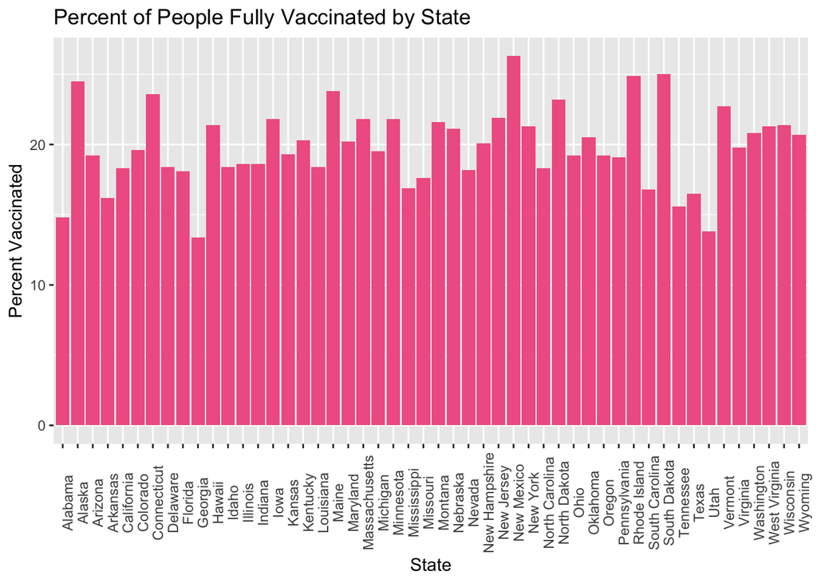

```r
covid19Data2$percent.Fully.Vaccinated <- as.numeric(covid19Data2$percent.Fully.Vaccinated)

ggplot(covid19Data2, aes(x = State, weight = percent.Fully.Vaccinated)) + geom_bar(fill = "#F06292") + theme(axis.text.x = element_text(angle = 90)) + ggtitle("Percent of People Fully Vaccinated by State") + xlab("State") + ylab("Percent Vaccinated")
```

```r
casesdeathsstates3 <- casesdeathsstates %>%
  rename(State = `State/Territory`, ) %>%
  filter(State != 'American Samoa', State != 'District of Columbia', State != 'Federated States of Micronesia', State != 'Guam', State != 'Northern Mariana Islands', State != 'New York City', State != 'Puerto Rico', State != 'Palau', State != 'Republic of Marshall Islands', State != 'Virgin Islands', State != 'United States of America')
casesdeathsstates3
```

```
## # A tibble: 50 x 13
##    State `Total Cases` `Confirmed Case… `Probable Cases` `Cases in Last …
##    <chr>         <dbl>            <dbl>            <dbl>            <dbl>
##  1 Alas…         61401                0                0             1691
##  2 Alab…        516918           402538           114380             2299
##  3 Arka…        331098                0                0             1090
##  4 Ariz…        844910           784860            60050             4418
##  5 Cali…       3582463                0                0            17995
##  6 Colo…        468988           439872            29116             9627
##  7 Conn…        316655           291943            24712             8216
##  8 Dela…         96577            90741             5836             2175
##  9 Flor…       2046280                0                0            36872
## 10 Geor…       1065197           856340           208857             8776
## # … with 40 more rows, and 8 more variables: `Case Rate per 100000` <dbl>,
## #   `Total Deaths` <dbl>, `Confirmed Deaths` <chr>, `Probable Deaths` <chr>,
## #   `Deaths in Last 7 Days` <dbl>, `Death Rate per 100000` <dbl>, `7-Day Cases
## #   Rate per 100000` <dbl>, `7-Day Death Rate per 100000` <dbl>
```

```r
dosesAdministered <- covid19Data2 %>%
  select(State, doses.Administered.Moderna, doses.Administered.Janssen, doses.Administered.Pfizer,
  doses.Administered.Unknown) %>%
  rename(
    moderna = doses.Administered.Moderna,
    pfizer = doses.Administered.Pfizer,
    janssen = doses.Administered.Janssen,
    unknown = doses.Administered.Unknown
  ) %>%
  pivot_longer(!State, names_to = "vaccineName", values_to = "administeredCount")
dosesAdministered
```

```
## # A tibble: 200 x 3
##    State    vaccineName administeredCount
##    <chr>    <chr>                   <dbl>
##  1 Alaska   moderna                196291
##  2 Alaska   janssen                  8180
##  3 Alaska   pfizer                 228162
##  4 Alaska   unknown                    57
##  5 Alabama  moderna                925296
##  6 Alabama  janssen                 47936
##  7 Alabama  pfizer                 923688
##  8 Alabama  unknown                     0
##  9 Arkansas moderna                639121
## 10 Arkansas janssen                 35472
## # … with 190 more rows
```

```r
fivestatesdoses <- covid19Data1 %>%
  right_join(dosesAdministered, by = "State") %>%
  filter(State %in% c("California", "Florida", "Texas", "New York", "Pennsylvania"))
fivestatesdoses
```

```
## # A tibble: 20 x 4
##    State        total.Doses.Administered vaccineName administeredCount
##    <chr>                           <dbl> <chr>                   <dbl>
##  1 California                   20485651 moderna               9501672
##  2 California                   20485651 janssen                520656
##  3 California                   20485651 pfizer               10461476
##  4 California                   20485651 unknown                  1847
##  5 Florida                      10645680 moderna               4952131
##  6 Florida                      10645680 janssen                281708
##  7 Florida                      10645680 pfizer                5396834
##  8 Florida                      10645680 unknown                 15007
##  9 New York                     10761342 moderna               4902121
## 10 New York                     10761342 janssen                306020
## 11 New York                     10761342 pfizer                5551538
## 12 New York                     10761342 unknown                  1663
## 13 Pennsylvania                  6802632 moderna               3080504
## 14 Pennsylvania                  6802632 janssen                154474
## 15 Pennsylvania                  6802632 pfizer                3567501
## 16 Pennsylvania                  6802632 unknown                   153
## 17 Texas                        13297711 moderna               6090226
## 18 Texas                        13297711 janssen                349769
## 19 Texas                        13297711 pfizer                6857078
## 20 Texas                        13297711 unknown                   638
```

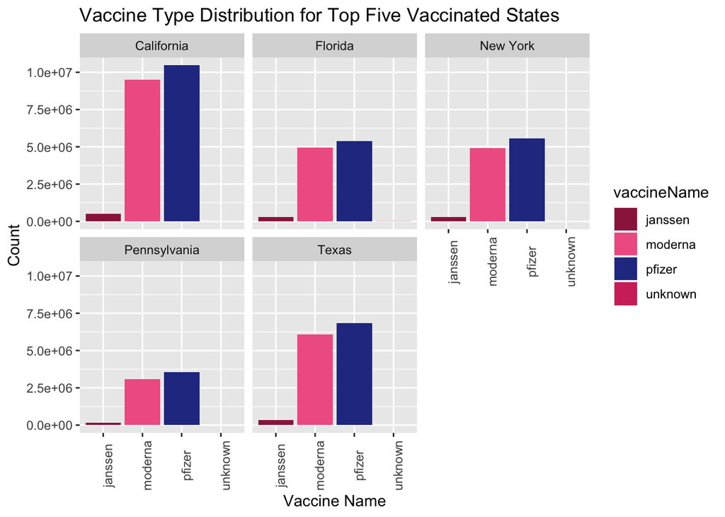

```r
ggplot(fivestatesdoses, aes(x = vaccineName, weight = administeredCount, fill = vaccineName)) + geom_bar() + facet_wrap(~State) + theme(axis.text.x = element_text(angle = 90)) + ggtitle("Vaccine Type Distribution for Top Five Vaccinated States") + xlab("Vaccine Name") + ylab("Count") + scale_fill_manual(values = c("janssen" = "#9C254D",
                             "moderna" = "#F06292",
                             "pfizer" = "#2A3990",
                             "unknown" = "#D23369"))
```

#Looking at these side-by-side bar charts, it’s clear that Pfizer is the most administered vaccine type in the top five vaccinated states. This makes sense because Pfizer is also the most popularly administered vaccine for the U.S. as a whole. Moderna is a close second, but Johnson & Johnson’s Janssen vaccine is rarely getting administered compared to the others. This could simply due to the fact that the Janssen vaccine was approved later than the others.